# Loan Prediction Machine Learning Project

### ROC curve

The ROC looks much better than that of the KNN model. From ~0.5 specificity onward, sensitivity sits near 1.0.

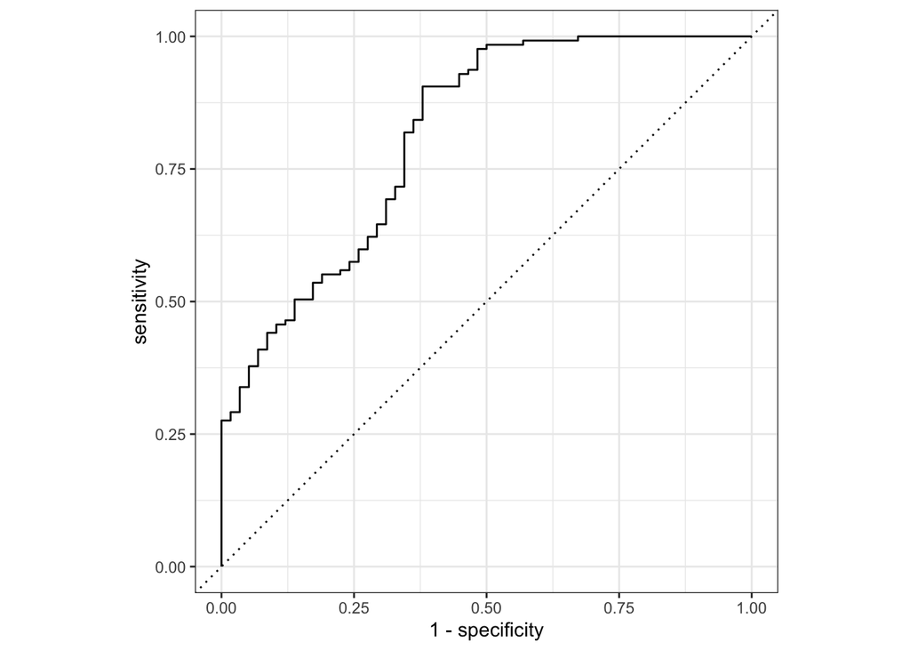

```r
augment(lda_fit, new_data = loan_test, type = 'prob') %>%
  roc_curve(Loan_Status, .pred_Yes) %>%
  autoplot()
```

# Conclusion

This project aimed to predict loan eligibility using select applicant demographics from a modest dataset with multiple features. I followed a structured workflow: data cleaning, exploratory analysis, and testing 6 models of varying complexity and flexibility. The LDA model performed best, though all models showed moderate accuracy (~0.7-0.8 `roc_auc`) with room for improvement.

Key challenges included assumption violations, overfitting, and dimensionality reduction. Linear models struggled to capture complex relationships, while non-parametric models tended to overfit.

The better test performance of discriminant models (LDA and QDA) suggest that the data likely includes a mix of linear and non-linear patterns, with LDA surprisingly capturing linear boundaries more effectively than expected.

Further refinements could involve exploring more flexible, non-linear models such as random forests or gradient boosting to better capture complex decision boundaries.

Limitations include possible confounds and missing features such as age or race, which could improve accuracy and reveal biases. Loan eligibility decisions based on limited demographics risk unfairness; a case-by-case basis is preferable.

[figure not shown]